# Lab 9:

Monday, March 02, 2015

## Ecological Fallacy

## What is the ecological fallacy?

The *ecological fallacy* is attempting to draw individual-level conclusions from aggregated group-level data. Often, the conclusions are incorrect.

If you want to draw a conclusion at a certain level, you need data collected *at that level*.

## UC Berkeley Grad Admissions (1973)

The `UCBAdmissions` data are built in to R. They're from a classic [paper in *Science*](http://brenocon.com/science_1975_sex_bias_graduate_admissions_data_berkeley.pdf). (They also have a very annoying structure - 3d array :( )

We have aggregate data for graduate admissions by gender and department for the 6 biggest departments. (The complete data would include 101 departments.)

## Aggregate data

```
##           Gender
## Admit      Male Female
##   Admitted 1198    557
##   Rejected 1493   1278
```

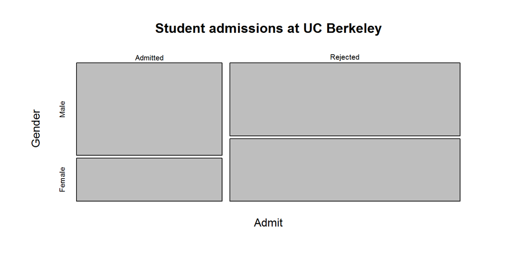

## Now look by department

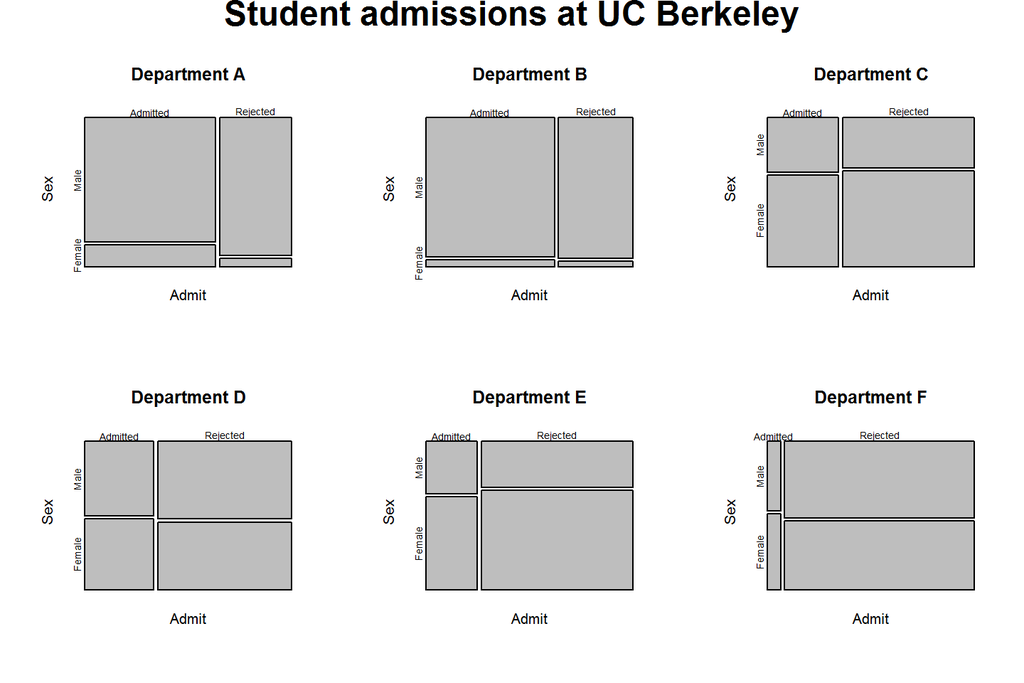

## Simpson's Paradox

The Berkeley data illustrates *Simpson's Paradox*, which is a special case of the Ecological Fallacy with two groups (men and women in this example). It's possible for group A to be more probable than group B in **every single individual case**, but still see the opposite if everything is pooled together.

[It has a nice Wikipedia page](https://en.wikipedia.org/wiki/Simpson%27s_paradox) with quite a few examples and a nicely simple graph illustration.

## Presidential Voting Patterns

In the 2004 presidential election, poor states (measured in median income) tended to vote for Bush, and rich states tended to vote for Kerry. So: can we conclude that poor people voted for Bush and rich people for Kerry?

- No! The opposite is true looking at individual-level data.

## Don't Create Fallacies

Sometimes the ecological fallacy is created by researchers regressing on aggregate measures *even in the presence of individual data*. Oft-cited reasons for aggregating before analysis are - simplifying - not wanting to fit individual lines - avoiding individuals with low numbers of observations

While it doesn't help much with "simplifying", using multilevel models / random effects can solve the other two concerns (as in the Radon example).

## Generalizing Surveys to Populations

In social sciences, often you have surveys that over- and under- represent certain groups in the population. Some surveys come with "survey weights" which are supposed to be used to adjust estimates to map to the whole population.

## Using survey weights is annoying

> Survey weighting is a mess. It is not always clear how to use weights in estimating anything more complicated than a simple mean or ratios, and standard errors are tricky even with simple weighted means.

(Gelman in [*Struggles with Survey Weighting and Regression Modeling*](http://www.stat.columbia.edu/~gelman/research/published/STS226.pdf)).

A more modern approach is called Multilevel Regression and Poststratification (MRP, "Mister P"), which relies heavily on multilevel modeling, is (perhaps) easier to understand for those with a decent grasp of random effects, and is *much* more flexible in the estimates you can get out. [One good sources is here](https://aje.oxfordjournals.org/content/179/8/1025.full).

## Flexibility of Mixed Models

One other point I want to make is that random effects can be combined with all of the other techniques we've learned. `lme4` supports GLMs well, and `mgcv` will let you include random effects with a GAM. (Though `mgcv` relies on `nlme` instead of `lme4`, so the syntax for specifying random effects is a little different.)

## Mixed Model Predictions

## Predictions for new data based on Mixed Models

Point estimates are easy, the `predict` has methods for `merMods` which work just fine.

Confidence intervals are hard.

From the (very thorough and nice) FAQ for [R-SIG-Mixed-Models](http://glmm.wikidot.com/faq), the general recipe for computing predictions from a linear or generalized linear model is to:

- figure out the model matrix X corresponding to the new data;
  - You'll always have to make new data. `model.matrix` will help expand factors into dummy variables
- matrix-multiply X by the parameter vector \(\beta\) to get the predictions (or linear predictor in the case of GLM(M)s);
  - We can just use `predict()` for this.
- extract the variance-covariance matrix of the parameters V;
- compute XVX' to get the variance-covariance matrix of the predictions;
- extract the diagonal of this matrix to get variances of predictions;
- if computing prediction rather than confidence intervals, add the residual variance;
- take the square-root of the variances to get the standard deviations (errors) of the predictions;
- compute confidence intervals based on a Normal approximation;
- for **G**LMMs, run the confidence interval boundaries (not the standard errors) through the inverse-link function.

## Do we have to do *all* of that?

Usually no. Gelman & Hill cut some corners in Chapter 12. (Later in the book, esp. Chapter 18, they are quite thorough.) We'll stick with the cut-corner version.

```r
# Get data and model
load("radon.RData")
fixed = lm(y ~ x + county, data = radon)
re = lmer(y ~ x + (1 | county), data = radon)
```

## New observation at existing level

Point estimates are easy. Let's predict, for county `1`, radon measurements for the basement and first floor (x = 0 and 1).

```r
# new data
county1 = data.frame(x = 0:1,
    county = factor(c(1, 1),
        levels = levels(radon$county)))
# point estimates
```

## Fixef model

```r
(fix.1 = predict(fixed, newdata = county1, se.fit = T))
```

```
## $fit
##         1         2
## 0.8405411 0.1200021
##
## $se.fit
##         1         2
## 0.3786561 0.3822085
##
## $df
## [1] 833
##
## $residual.scale
## [1] 0.7564195
```

## Ranef model

```r
(re.1 = predict(re, newdata = county1))
```

```
##         1         2
## 1.1915004 0.4985066
```

We could stop here if we don't need confidence intervals.

## Simuluating CI

Simulation is the best way to get a good CI for a mixed effects model prediction. For a predictive estimate \(\tilde y\) based on new data \(\tilde x\) in group \(j\):

\[ \tilde{y} | \theta \sim \mathcal{N}(\alpha_j + \beta \tilde{x}, \sigma^2_y) \]

With this example, it still is pretty easy, but it generalizes to cases with more error terms.

```r
j = 1       # county 1
x.tilde = 1 # for 1st floor
# arm::sigma.hat, quite useful for residual error extraction
sigma.y.hat = sigma.hat(re)$sigma$data
coef.hat    = as.matrix(coef(re)$county)[j, ]
y.tilde     = rnorm(1000, coef.hat %*% cbind(1, x.tilde), sigma.y.hat)
```

```r
quantile(y.tilde, c(.025, .25, .5, .75, .975))
```

[output not shown]

## Out-of-sample prediction

Point estimate:

```r
predict(re, newdata = data.frame(x = 0:1, county = c(86, 86)),
        allow.new.levels = TRUE)
```

```
##         1         2
## 1.4615979 0.7686041
```

## Out-of-sample CI

For a new county, we don't have an estimated intercept, so we sample that as well:

```r
n.sims = 1000
a.hat = fixef(re)["(Intercept)"]
sigma.a.hat = sigma.hat(re)$sigma$county
a.tilde = rnorm(n.sims, a.hat, sigma.a.hat)
y.tilde = rnorm(n.sims, a.tilde + coef.hat["x"] %*% x.tilde, sigma.y.hat)
mean(y.tilde)
```

```
## [1] 0.7831715
```

```r
quantile(y.tilde, c(0.25, .5, .75))
```

```
##       25%       50%       75%
## 0.2391889 0.7945033 1.3206049
```